# Simple Linear Regression

Numerical vs. numerical

[Dr. Peng Zhao](https://connect.xjtlu.edu.cn/user/pengzhao) (✉ peng.zhao@xjtlu.edu.cn)

Department of Health and Environmental Sciences  
Xi’an Jiaotong-Liverpool University

# 1 Learning objectives

In this lecture, you will

1. Explore a relationship between two numeric variables,
2. Work with regression,
3. Understand what correlation is all about,
4. Discover how correlation connects to regression, and
5. Visualize linear regression and correlations.

# 2 Definitions

- *X*: the independent variable. Input or cause variables. Synonyms: predictor variable, regressor, controlled variable, manipulated variable, explanatory variable, exposure variable, risk factor, feature and input variable.
- *Y*: the dependent variable. Output or effect variables. Synonyms: Response variable, regressand, measured variable, responding variable, explained variable, outcome variable, experimental variable, and output variable.
- Regressing *Y* on *X*

Assumptions:

1. Values of *X* are “fixed” and non-random.
2. *X* is measured without error.
3. For each value of *X* there is a subpopulation of values of *Y* that are normally distributed.
4. **Assumption of homoskedasticity**: The variances of the sub-populations of *Y* are equal.
5. **Assumption of linearity**: The means of the sub-populations of *Y* all lie on the same straight line $\mu_{y|x} = \alpha + \beta x$
6. The *Y* values are statistically independent.

Simple linear regression (SLR) model:

$$y' = \alpha + \beta x +\epsilon$$

$$\epsilon = y' - (\alpha + \beta x) = y' - \mu_{y|x}$$

**$\epsilon$:**

The error term. The amount by which an observation *y* deviates from the mean of the subpopulation of *Y* values from which it is drawn.

$$y' = a + bx$$

**$a, b$:**

The regression coefficients. $a$ is the intercept, i.e. the point where the line crosses the vertical axis, and $b$ is the slope.

**The regression line (The Least Squares Line):**

The best fitting line, which passes through the maximum number of points and isn’t too far away from the points that it does not pass through.

- The distances in the vertical direction between the points is a minimum — the minimal sum of the square of these distances ($\sum(y'-y)^2$).

$$b = \frac{\sum(x-\bar x)(y -\bar y)}{\sum(x-\bar x)^2}$$

$$a = \bar y - b\bar x$$

**Residual:**

$y-y'$ (Deviations of the observed $y$-values around the predicted $y$-values)

**Residual variance:**

roughly an average of the squared residuals:

$$s^2_{yx} = \frac{\sum(y-y')^2}{n-2}$$

**Residual standard error:**

$s_{yx} = \sqrt\frac{\sum(y-y')^2}{n-2}$

**Correlation:**

The technique used to assess two variables that have a co-relationship with one another.

**Positive correlation:**

High values on one are associated with high values on the other.

**Negative correlation:**

High values on one are associated with low values on the other.

**Population Correlation Coefficient ($\rho$):**

The parameter which measures the strength of the linear relationship.

- $-1 \le \rho \le +1$.
- $\rho = −1$: perfect negative correlation between the two variables
- $\rho = 1$: perfect positive correlation.
- $\rho = 0$: the two variables are not linearly correlated.

Sample correlation coefficient $r$:

$$r = \frac{\frac{1}{n-1} \sum(x-\bar x)(y - \bar y)}{s_x s_y}$$

or:

$$r = \frac{\mathrm{cov}(x,y)}{s_x s_y}$$

**$\mathrm{cov}(x,y)$:**

covariance, which represents $x$ and $y$ varying together.

| Correlation Coefficient (r) | Description (Rough Guideline ) |
| --- | --- |
| +1.0 | Perfect + association |
| +0.8 to 1.0 | Very strong + association |
| +0.6 to 0.8 | Strong + association |
| +0.4 to 0.6 | Moderate + association |
| +0.2 to 0.4 | Weak + association |
| 0.0 to +0.2 | Very weak + or no association |
| 0.0 to -0.2 | Very weak - or no association |
| -0.2 to – 0.4 | Weak - association |
| -0.4 to -0.6 | Moderate - association |
| -0.6 to -0.8 | Strong - association |
| -0.8 to -1.0 | Very strong - association |
| -1.0 | Perfect negative association |

**$R^2$:**

Coefficient of determination.

# 3 Example

*students_env221.csv*: Predict the shoe size of a student. What is the best prediction for a student I do not know?

- The mean.

```
[1] 39.5
```

The more information about the students, the more accurate prediction.

Calculate the correlation coefficient for the height and shoe size data.

```r
cor(dtf$HEIGHT, dtf$SHOE)
```

```
[1] 0.8473755
```

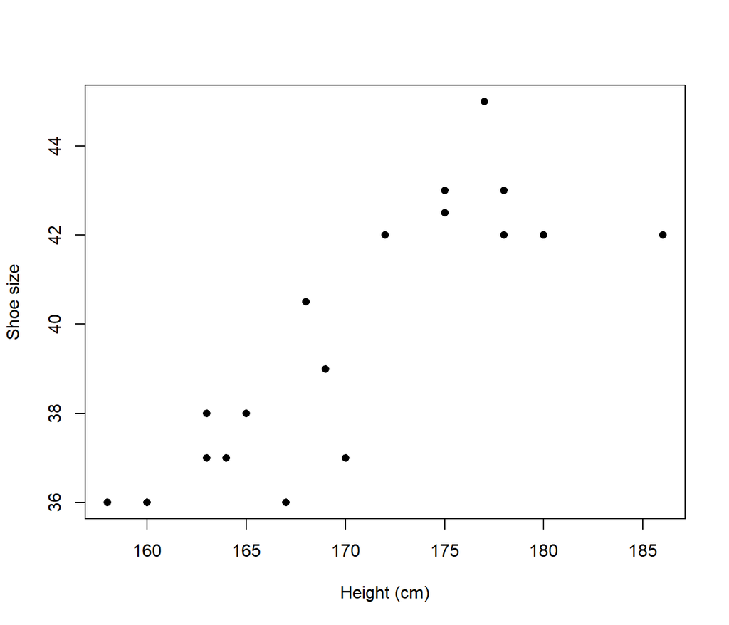

Generally, a tall student has a large shoe size.

Then, if we know a student’s height, can we predict her/his shoe size better than using the mean?

- Draw a line to summarize the relationship in the scatter plot.
- We can draw many many lines. Which one best summarizes the relationship? – SLR

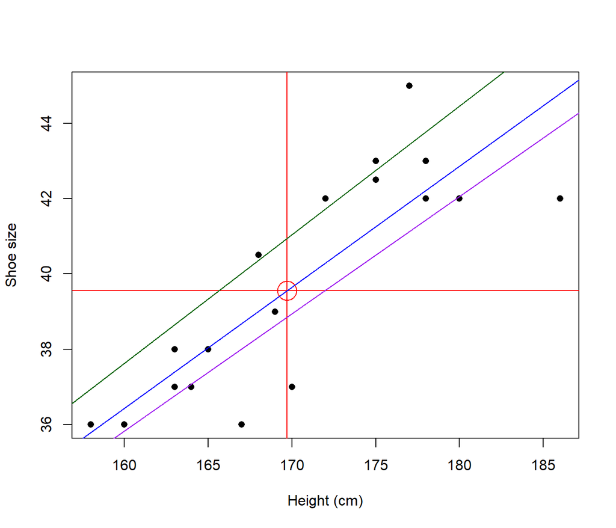

# 4 Interpretation

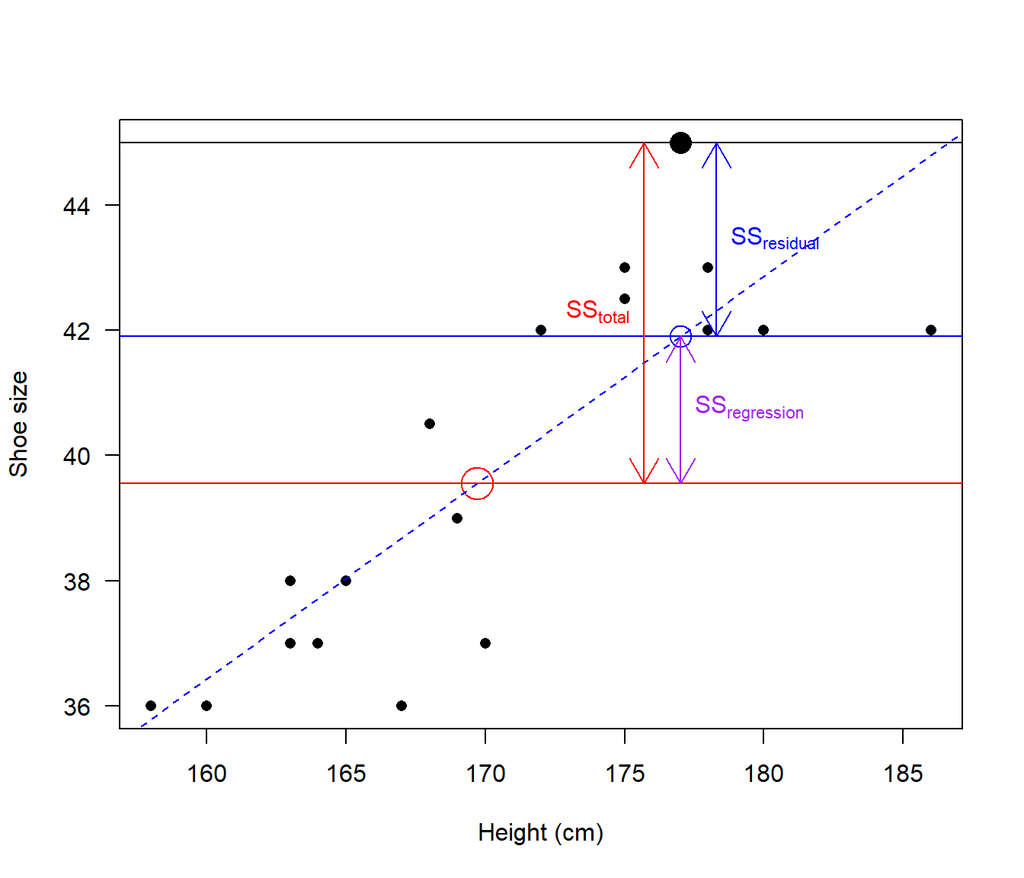

$$y_i - \bar y = (y_i-y') + (y'-\bar y)$$

**$\sum(y_i-y')^2$:**

The residual sum of squares ($SS_\mathrm{residual}$).

**$\sum(y'-\bar y)^2$:**

The regression sum of squares ($SS_\mathrm{regression}$). The gain in prediction due to using the regression line rather than using the mean.

**$\sum(y_i -\bar y)^2$:**

The total sum of squares ($SS_\mathrm{total}$). The numerator of the variance of $y$. The numerator of the total variance.

$$SS_\mathrm{residual} + SS_\mathrm{regression} = SS_\mathrm{total}$$

$$df_\mathrm{residual} + df_\mathrm{regression} = df_\mathrm{total}$$

$$df_\mathrm{regression} = 1$$

$$df_\mathrm{total} = n - 1$$

$$df_\mathrm{residual} = n - 2$$

| Source | $df$ | $SS$ (Sum of squares) | $MS$ (Mean of squares) | $F$ |
| --- | --- | --- | --- | --- |
| between the obs. and the mean | $df_\mathrm{total} = n - 1$ | $SS_\mathrm{total} = \sum(y_i -\bar y)^2$ | $MS_\mathrm{total} = \frac{SS_\mathrm{total}}{df_\mathrm{total}}$ | $F = \frac{MS_\mathrm{regression}}{MS_\mathrm{residual}}$ |
| between the obs. and the regression line | $df_\mathrm{residual} = n - 2$ | $SS_\mathrm{residual} = \sum(y_i-y')^2$ | $MS_\mathrm{residual} = \frac {SS_\mathrm{residual}}{df_\mathrm{residual}}$ |  |
| between the regression line and the mean | $df_\mathrm{regression} = 1$ | $SS_\mathrm{regression} = \sum(y'-\bar y)^2$ | $MS_\mathrm{regression} = \frac{SS_\mathrm{regression}}{df_\mathrm{regression}}$ |  |

- If $H_0$ is true (i.e. no relationship between $x$ and $y$), $MS_\mathrm{regression}$ should be no greater than $MS_\mathrm{residual}$.
- If $H_0$ is false (i.e. relationship between $x$ and $y$), $MS_\mathrm{regression}$ should be greater than $MS_\mathrm{residual}$.

Is there relationship between $X$ and $Y$?

1. Hypotheses
- $H_0$: There is no relationship between the height and the shoe size.
- $H_1$: There is relationship between the height and the shoe size.
- Question: Reject $H_0$? Given $\alpha$.

Equivalent hypotheses:

- $H_0: \sigma ^2_\mathrm{regression} \le \sigma ^2_\mathrm{residual}$
- $H_1: \sigma ^2_\mathrm{regression} > \sigma ^2_\mathrm{residual}$
- $F$-test
2. Collect data.
3. Calculate a test statistic.

```r
env_lm <- lm(SHOE ~ HEIGHT, data = dtf)
env_lm
```

```
Call:
lm(formula = SHOE ~ HEIGHT, data = dtf)

Coefficients:
(Intercept)       HEIGHT
   -15.0218       0.3216
```

```r
env_lm$coefficients
```

```
(Intercept)      HEIGHT
-15.0217688   0.3215779
```

```r
summary(env_lm)
```

```
Call:
lm(formula = SHOE ~ HEIGHT, data = dtf)

Residuals:
    Min      1Q  Median      3Q     Max
-2.7917 -0.5023 -0.1288  0.8971  3.1025

Coefficients:
            Estimate Std. Error t value Pr(>|t|)
(Intercept) -15.0218     8.0679  -1.862    0.079 .
HEIGHT        0.3216     0.0475   6.771 2.42e-06 ***
---
Signif. codes:  0 '***' 0.001 '**' 0.01 '*' 0.05 '.' 0.1 ' ' 1

Residual standard error: 1.575 on 18 degrees of freedom
Multiple R-squared:  0.718, Adjusted R-squared:  0.7024
F-statistic: 45.84 on 1 and 18 DF,  p-value: 2.419e-06
```

4. Decision.

Reject $H_0$.

5. Conclusion. There is relationship between the body height and the shoe size.

## 4.1 Reporting correlations and regressions

Correlation:

- the degrees of freedom in parentheses
- the *r* value (the correlation coefficient)
- the *p* value

Regression:

- the *R*<sup>2</sup> value (the coefficient of determination)
- the *F* value (also referred to as the *F* statistic)
- the [degrees of freedom](https://www.scribbr.com/statistics/degrees-of-freedom/) in parentheses
- the *p* value

Example:

- SAT scores predicted college GPA, *R*<sup>2</sup> = 0.34, *F*(1, 416) = 6.71, *p* = 0.009.

# 5 Visualization

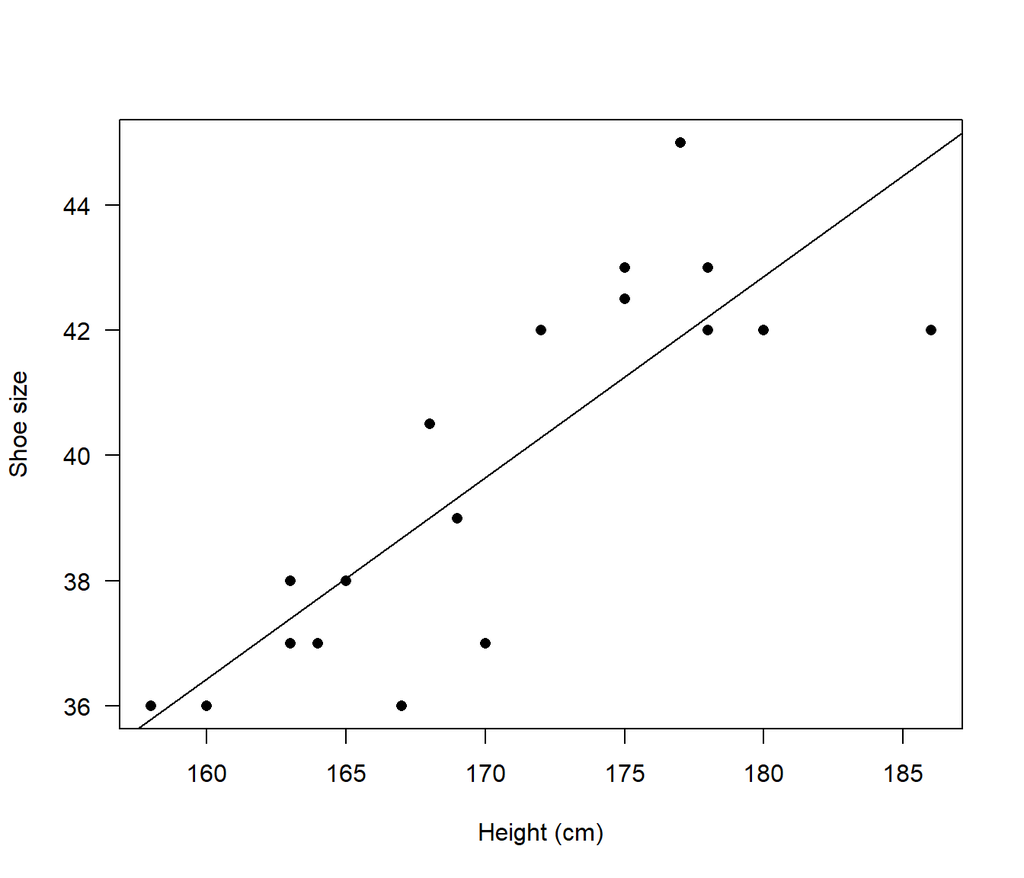

```r
plot(dtf$HEIGHT, dtf$SHOE, xlab = 'Height (cm)', ylab = 'Shoe size', las = 1, pch = 16)
abline(lm_env)
```

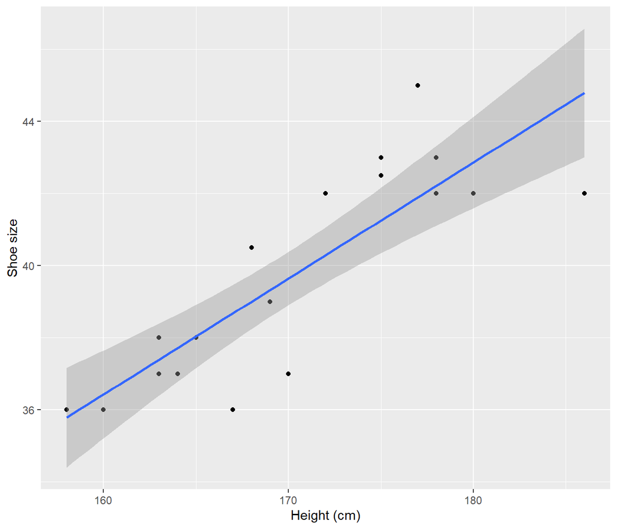

```r
library(ggplot2)
ggplot(dtf, aes(HEIGHT, SHOE)) +
  geom_point() +
  geom_smooth(method = "lm") +
  labs(x = 'Height (cm)', y = 'Shoe size')
```

The **corrplot** package:

```r
library(corrplot)
icor <- cor(dtf[, 3:4], use = "complete.obs")
corrplot(icor)
icor <- cor(airquality, use = "complete.obs")
par(mfrow = c(4, 2))
corrplot(icor)
corrplot(icor, order = "AOE")
corrplot(icor, order = "AOE", method = "number")
corrplot(icor, order = "AOE", method = "ellipse")
corrplot(icor, order = "AOE", method = "shade")
corrplot(icor, order = "AOE", method = "pie")
corrplot(icor, order = "AOE", addCoef.col = "grey")
corrplot(icor, order = "AOE", type = "upper")
corrplot(icor, order = "AOE", type = "lower", method = "ell",
         diag = FALSE, tl.pos = "n", cl.pos = "n", add = TRUE)
```

[output not shown]

The **GGally** package:

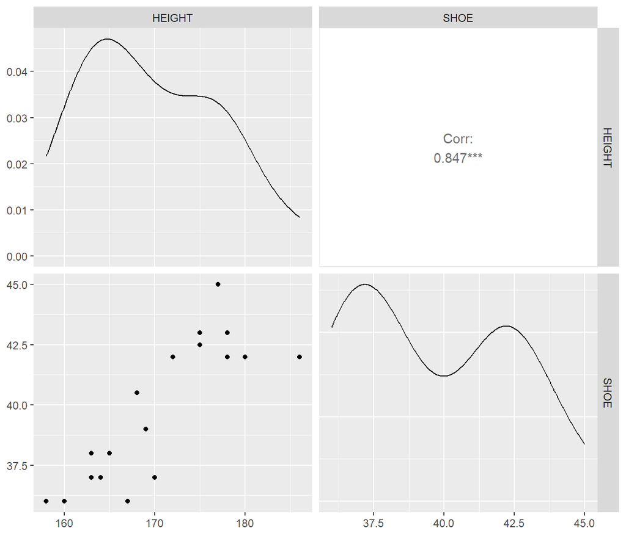

```r
library(GGally)
ggpairs(dtf[, c("HEIGHT", "SHOE")])
```

# 6 Readings

- [R Tutorials on TechVidvan](https://techvidvan.com/tutorials/learn-r-programming/):
  - [Linear Regression in R](https://techvidvan.com/tutorials/linear-regression-in-r/)
- STAT 501, Pennsylvania State University
  - [Lesson 1: Simple Linear Regression](https://online.stat.psu.edu/stat501/lesson/1)
  - [Lesson 2: SLR Model Evaluation](https://online.stat.psu.edu/stat501/lesson/2)
  - [Lesson 3: SLR Estimation & Prediction](https://online.stat.psu.edu/stat501/lesson/3)
  - [Lesson 4: SLR Model Assumptions](https://online.stat.psu.edu/stat501/lesson/4)